# R Notebook

# Homework Week 6_day 03

##Q1 Load the data again, clean_names(), and re-familiarise yourself with it

```r
ames <- read_csv("data/ames.csv") %>%
  clean_names()
```

```r
glimpse(ames)
```

```
Rows: 2,930
Columns: 82
$ order           <dbl> 1, 2, 3, 4, 5, 6, 7, 8, 9, 10, 11, 12, 13, 14, 15, 16, 17, 18, 19, 20, 21, 22, 23, 24, 25, 26, 27, 28, 29, 30, 31, 32, 33, 34, 3…
$ pid             <dbl> 526301100, 526350040, 526351010, 526353030, 527105010, 527105030, 527127150, 527145080, 527146030, 527162130, 527163010, 5271652…
$ ms_sub_class    <dbl> 20, 20, 20, 20, 60, 60, 120, 120, 120, 60, 60, 20, 60, 20, 120, 60, 50, 20, 20, 20, 20, 85, 60, 20, 20, 20, 20, 20, 120, 160, 16…
$ ms_zoning       <chr> "RL", "RH", "RL", "RL", "RL", "RL", "RL", "RL", "RL", "RL", "RL", "RL", "RL", "RL", "RL", "RL", "RL", "RL", "RL", "RL", "RL", "R…
$ lot_frontage    <dbl> 141, 80, 81, 93, 74, 78, 41, 43, 39, 60, 75, NA, 63, 85, NA, 47, 152, 88, 140, 85, 105, 85, NA, NA, NA, 65, 70, 70, 26, 21, 21, …
$ lot_area        <dbl> 31770, 11622, 14267, 11160, 13830, 9978, 4920, 5005, 5389, 7500, 10000, 7980, 8402, 10176, 6820, 53504, 12134, 11394, 19138, 131…
$ street          <chr> "Pave", "Pave", "Pave", "Pave", "Pave", "Pave", "Pave", "Pave", "Pave", "Pave", "Pave", "Pave", "Pave", "Pave", "Pave", "Pave", …
$ alley           <chr> NA, NA, NA, NA, NA, NA, NA, NA, NA, NA, NA, NA, NA, NA, NA, NA, NA, NA, NA, NA, NA, NA, NA, NA, NA, NA, NA, NA, NA, NA, NA, NA, …
$ lot_shape       <chr> "IR1", "Reg", "IR1", "Reg", "IR1", "IR1", "Reg", "IR1", "IR1", "Reg", "IR1", "IR1", "IR1", "Reg", "IR1", "IR2", "IR1", "Reg", "R…
$ land_contour    <chr> "Lvl", "Lvl", "Lvl", "Lvl", "Lvl", "Lvl", "Lvl", "HLS", "Lvl", "Lvl", "Lvl", "Lvl", "Lvl", "Lvl", "Lvl", "HLS", "Bnk", "Lvl", "L…
$ utilities       <chr> "AllPub", "AllPub", "AllPub", "AllPub", "AllPub", "AllPub", "AllPub", "AllPub", "AllPub", "AllPub", "AllPub", "AllPub", "AllPub"…
$ lot_config      <chr> "Corner", "Inside", "Corner", "Corner", "Inside", "Inside", "Inside", "Inside", "Inside", "Inside", "Corner", "Inside", "Inside"…
$ land_slope      <chr> "Gtl", "Gtl", "Gtl", "Gtl", "Gtl", "Gtl", "Gtl", "Gtl", "Gtl", "Gtl", "Gtl", "Gtl", "Gtl", "Gtl", "Gtl", "Mod", "Mod", "Gtl", "G…
```

[output cut: 69 more lines]

##Q2 Investigate the distribution of lot_area. Is the distribution roughly normal? If not, what problems do you find?

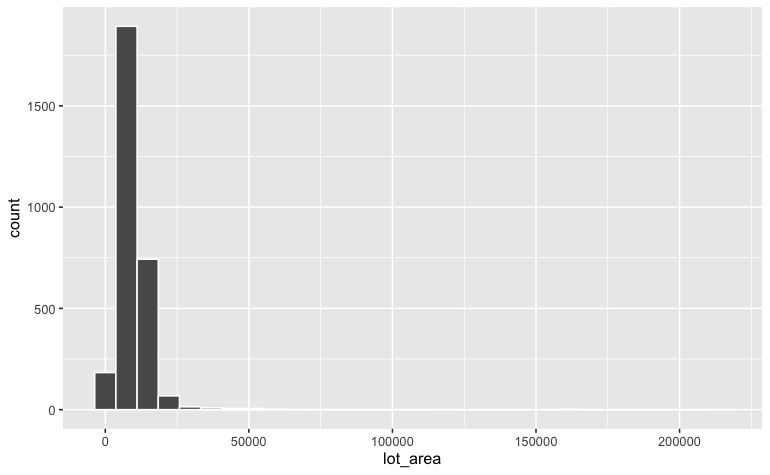

##Q3 Compute and visualise a bootstrap sampling distribution for the mean(lot_area) of the sold houses

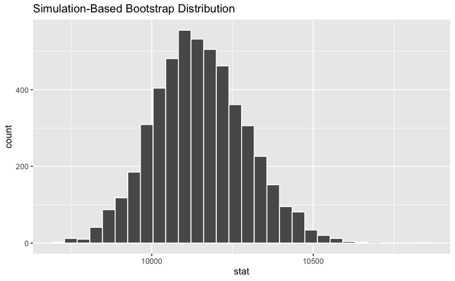

##Q4 Use your bootstrap distribution to calculate a 95% CI for mean(lot_area), and visualise it on the distribution

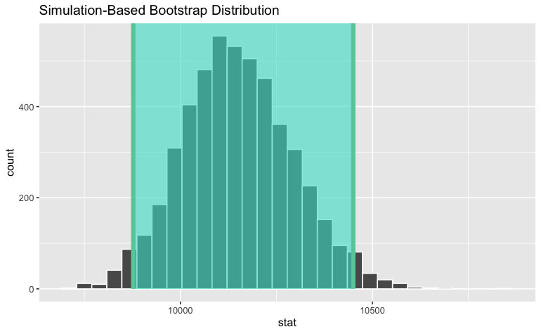

## Q5

You would like to know the mean(lot_area) of the sold houses with higher confidence. Calculate the 99% CI for this variable (you can re-use your bootstrap distribution from above). Is it narrower or broader than the 95% CI? Does that make sense?

```r
bootstrap_sampling
```

```
Response: lot_area (numeric)
```

| replicate | stat |
| --- | --- |
| 1 | 10276.371 |
| 2 | 10164.467 |
| 3 | 10458.249 |
| 4 | 10037.634 |
| 5 | 10175.903 |
| 6 | 10181.699 |
| 7 | 10031.828 |
| 8 | 9969.059 |
| 9 | 10031.626 |
| 10 | 10112.319 |

[output cut: 990 more lines]

infer_ci_95 -> [9877, 10450] infer_ci_99 -> [9814, 10535] The 99% CI is broader than the 95% CI, this does make sense!

With 99%, you increase the area you want your sample points to fall in. This is wider with 99% of your data, compared to 95% of your data (this is a narrower window)

##Q6 Calculate the point estimate of the mean(lot_area)

| mean |
| --- |
| 10149.66 |

-> point estimate of the mean(lot_area) -> 10149.66